# Apartado 9.7 Ejercicio 7

Daniel Ceballos Monsalve

Andrés Felipe Mejía Quintero

Doris Steffania Obando Gonzalez

Librerias a utilizar

```r
library(ISLR)
library(e1071)
library(ggplot2)
```

## Ejercicio 7

En este problema, utilizará enfoques de vectores de soporte para predecir si un automóvil determinado obtiene un consumo alto o bajo de combustible en función del conjunto de datos Auto.

### Enunciado a:

Cree una variable binaria que tome un 1 para los automóviles con rendimiento de gasolina por encima de la mediana y un 0 para automóviles con rendimiento de combustible por debajo de la mediana

```r
mediana = median(Auto$mpg)
Nivel_Gason = ifelse(Auto$mpg > mediana, 1, 0)
Auto$Nivel_Gason = as.factor(Nivel_Gason)
```

### Enunciado b:

Ajuste un clasificador de vectores de soporte a los datos con varios valores de costo, para predecir si un automóvil obtiene un alto o bajo consumo de combustible. Informe los errores de validación cruzada asociados con diferentes valores de este parámetro. Comente sus resultados.

```r
set.seed(2000)
Tuning_Lineal = tune(svm, Nivel_Gason ~ ., data = Auto, kernel = "linear",
              ranges = list(cost = c(0.001, 0.01,0.1, 1, 5, 10, 20, 30)),
              scale = TRUE)

summary(Tuning_Lineal)
```

```
##
## Parameter tuning of 'svm':
##
## - sampling method: 10-fold cross validation
##
## - best parameters:
##  cost
##     1
##
## - best performance: 0.01275641
##
## - Detailed performance results:
##    cost      error dispersion
## 1 1e-03 0.09955128 0.06892279
## 2 1e-02 0.07660256 0.06735702
## 3 1e-01 0.05365385 0.05857511
## 4 1e+00 0.01275641 0.01808165
## 5 5e+00 0.01782051 0.01724506
## 6 1e+01 0.02294872 0.02243651
## 7 2e+01 0.02807692 0.02823231
## 8 3e+01 0.03064103 0.02913640
```

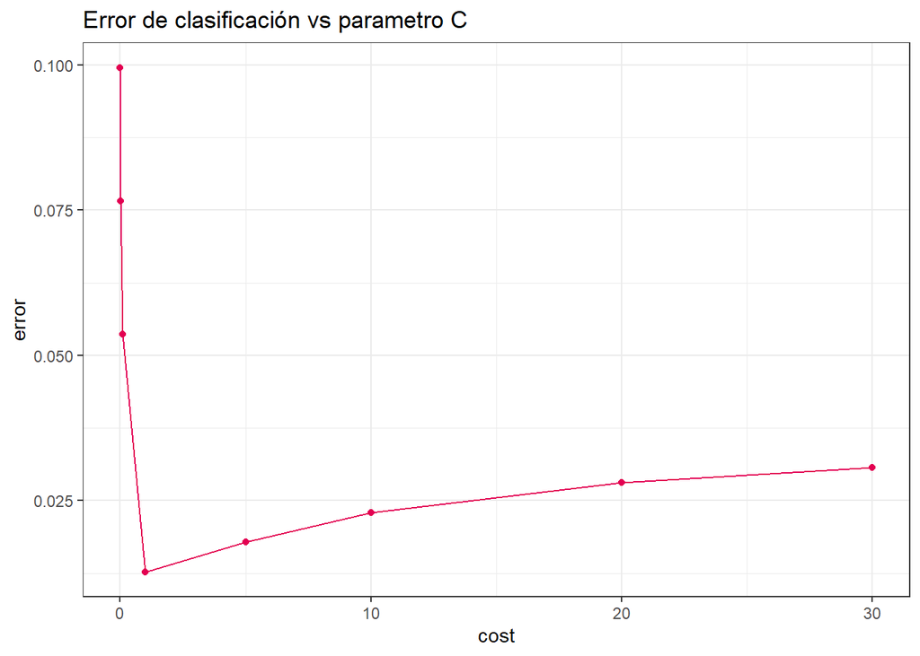

```r
ggplot(data = Tuning_Lineal$performances, aes(x = cost, y = error)) +
  geom_line(color= "#E30052") +
  geom_point(color="#E30052") +
  labs(title = "Error de clasificación vs parametro C") +
  theme_bw()
```

```r
paste("EL MEJOR MODELO ESTÁ CONFIGURADO DE LA SIGUIENTE FORMA:")
```

[output not shown]

```r
summary(Tuning_Lineal$Best_Modelo)
```

```
## Length  Class   Mode
##      0   NULL   NULL
```

### Enunciado c:

Ahora repita (b), esta vez usando SVM con núcleos de base radial y polinomial, con diferentes valores de gamma y grado y costo. Comente sus resultados.

```r
set.seed(500)
Tuning_Poli = tune(svm, Nivel_Gason ~ ., data = Auto, kernel = "polynomial",
                    ranges = list(cost = c(0.1, 1, 5, 10, 15, 20),
                    degree = c(2, 3, 4)),
                    scale = TRUE)
summary(Tuning_Poli)
```

```
##
## Parameter tuning of 'svm':
##
## - sampling method: 10-fold cross validation
##
## - best parameters:
##  cost degree
##    20      2
##
## - best performance: 0.4345513
##
## - Detailed performance results:
##    cost degree     error dispersion
## 1   0.1      2 0.5585897 0.04751014
## 2   1.0      2 0.5585897 0.04751014
## 3   5.0      2 0.5585897 0.04751014
## 4  10.0      2 0.5047436 0.10424863
## 5  15.0      2 0.5021795 0.07973906
## 6  20.0      2 0.4345513 0.11803325
## 7   0.1      3 0.5585897 0.04751014
## 8   1.0      3 0.5585897 0.04751014
## 9   5.0      3 0.5585897 0.04751014
## 10 10.0      3 0.5585897 0.04751014
## 11 15.0      3 0.5585897 0.04751014
## 12 20.0      3 0.5585897 0.04751014
## 13  0.1      4 0.5585897 0.04751014
## 14  1.0      4 0.5585897 0.04751014
## 15  5.0      4 0.5585897 0.04751014
## 16 10.0      4 0.5585897 0.04751014
## 17 15.0      4 0.5585897 0.04751014
## 18 20.0      4 0.5585897 0.04751014
```

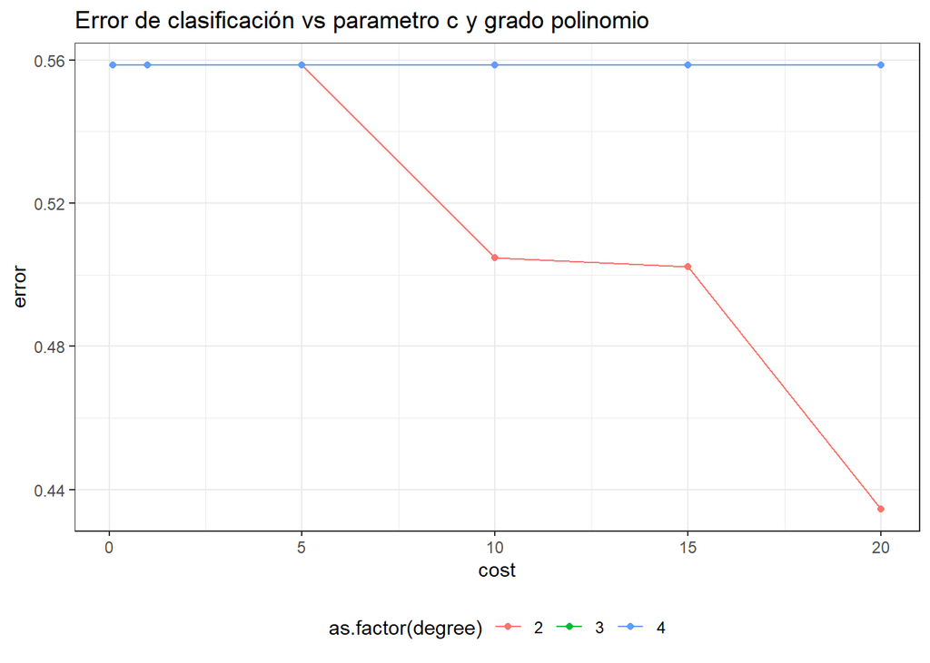

```r
ggplot(data = Tuning_Poli$performances, aes(x = cost, y = error, col = as.factor(degree))) +
  geom_line() +
  geom_point() +
  labs(title = "Error de clasificación vs parametro c y grado polinomio") +
  theme(plot.title = element_text(hjust = 0.5)) +
  theme_bw() + theme(legend.position = "bottom")
```

```r
paste("EL MEJOR MODELO ESTÁ CONFIGURADO DE LA SIGUIENTE FORMA:")
```

[output not shown]

```r
summary(Tuning_Poli$Best_Modelo)
```

```
## Length  Class   Mode
##      0   NULL   NULL
```

```r
set.seed(600)
Tuning_Radial = tune(svm, Nivel_Gason ~ ., data = Auto, kernel = "radial",
                    ranges = list(cost = c(0.1, 1, 5, 10,20),
                    gamma = c(0.01, 0.1, 1, 5, 10, 20,50)))
summary(Tuning_Radial)
```

```
##
## Parameter tuning of 'svm':
##
## - sampling method: 10-fold cross validation
##
## - best parameters:
##  cost gamma
##    20  0.01
##
## - best performance: 0.01525641
##
## - Detailed performance results:
##    cost gamma      error dispersion
## 1   0.1  0.01 0.08955128 0.04406483
## 2   1.0  0.01 0.07416667 0.04432105
```

[output cut: 33 more lines]

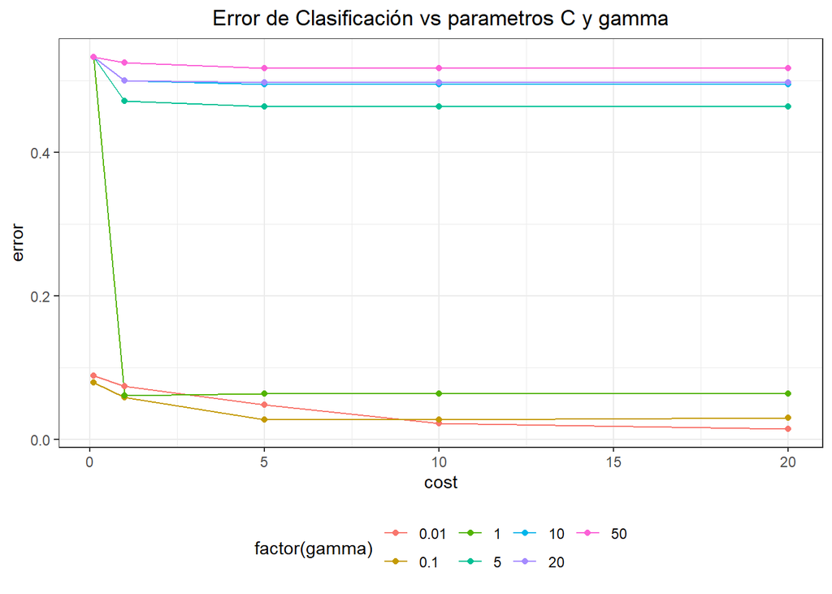

```r
ggplot(data = Tuning_Radial$performances, aes(x = cost, y = error, color = factor(gamma))) +
  geom_line() +
  geom_point() +
  labs(title = "Error de Clasificación vs parametros C y gamma") +
  theme_bw() +
  theme(plot.title = element_text(hjust = 0.5)) +
  theme(legend.position = "bottom")
```

```r
paste("EL MEJOR MODELO ESTÁ CONFIGURADO DE LA SIGUIENTE FORMA:")
```

[output not shown]

```r
summary(Tuning_Radial$Best_Modelo)
```

```
## Length  Class   Mode
##      0   NULL   NULL
```

### Enunciado d:

Haga algunas gráficas para respaldar sus afirmaciones en (b) y (c). Sugerencia: En el laboratorio, usamos la función plot () para objetos svm solo en casos con p = 2. Cuando p> 2, puede usar la función plot () para crear gráficos que muestren pares de variables a la vez. Esencialmente, en lugar de escribir > trama (svmfit, dat)

donde svmfit contiene su modelo ajustado y dat es un marco de datos que contiene sus datos, puede escribir > trama (svmfit, dat, x1∼x4)

para graficar solo la primera y cuarta variables. Sin embargo, tu debes reemplazar x1 y x4 con los nombres de variables correctos. Encontrar más, escriba? plot.svm.

```r
#mpg y displacement
datos = Auto[,c("mpg", "displacement", "Nivel_Gason")]
ggplot() +
geom_point(data = datos, aes(x = mpg, y = displacement, color = Nivel_Gason), size = 3) +
geom_point(data = datos[Tuning_Lineal$Best_Modelo$index, ],
           aes(x = mpg, y = displacement, color = Nivel_Gason),
           shape = 21, colour = "yellow",
           size = 5) +
theme(plot.title = element_text(hjust = 0.5)) +
theme_bw() + theme(legend.position = "top") +
theme(panel.background = element_rect(fill='gray8', colour='gray8'))
```

[output not shown]

```r
#mpg y horsepower
datos = Auto[,c("mpg", "horsepower", "Nivel_Gason")]
ggplot() +
geom_point(data = datos, aes(x = mpg, y = horsepower, color = Nivel_Gason), size = 3) +
geom_point(data = datos[Tuning_Lineal$Best_Modelo$index, ],
           aes(x = mpg, y = horsepower, color = Nivel_Gason),
           shape = 21, colour = "yellow",
           size = 5) +
theme(plot.title = element_text(hjust = 0.5)) +
theme_bw() + theme(legend.position = "top") +
theme(panel.background = element_rect(fill='gray8', colour='gray8'))
```

[output not shown]

```r
#mpg y year
datos = Auto[,c("mpg", "year", "Nivel_Gason")]
ggplot() +
geom_point(data = datos, aes(x = mpg, y = year, color = Nivel_Gason), size = 3) +
geom_point(data = datos[Tuning_Lineal$Best_Modelo$index, ],
           aes(x = mpg, y = year, color = Nivel_Gason),
           shape = 21, colour = "yellow",
           size = 5) +
theme(plot.title = element_text(hjust = 0.5)) +
theme_bw() + theme(legend.position = "top") +
theme(panel.background = element_rect(fill='gray8', colour='gray8'))
```

[output not shown]

```r
#mpg y acceleration
datos = Auto[,c("mpg", "acceleration", "Nivel_Gason")]
ggplot() +
geom_point(data = datos, aes(x = mpg, y = acceleration, color = Nivel_Gason), size = 3) +
geom_point(data = datos[Tuning_Lineal$Best_Modelo$index, ],
           aes(x = mpg, y = acceleration, color = Nivel_Gason),
           shape = 21, colour = "yellow",
           size = 5) +
theme(plot.title = element_text(hjust = 0.5)) +
theme_bw() + theme(legend.position = "top") +
theme(panel.background = element_rect(fill='gray8', colour='gray8'))
```

[output not shown]

```r
#mpg y displacement
datos = Auto[,c("mpg", "displacement", "Nivel_Gason")]
ggplot() +
geom_point(data = datos, aes(x = mpg, y = displacement, color = Nivel_Gason), size = 3) +
geom_point(data = datos[Tuning_Poli$Best_Modelo$index, ],
           aes(x = mpg, y = displacement, color = Nivel_Gason),
           shape = 21, colour = "yellow",
           size = 3) +
theme(plot.title = element_text(hjust = 0.5)) +
theme_bw() + theme(legend.position = "top") +
theme(panel.background = element_rect(fill='gray8', colour='gray8'))
```

[output not shown]

```r
#mpg y horsepower
datos = Auto[,c("mpg", "horsepower", "Nivel_Gason")]
ggplot() +
geom_point(data = datos, aes(x = mpg, y = horsepower, color = Nivel_Gason), size = 3) +
geom_point(data = datos[Tuning_Poli$Best_Modelo$index, ],
           aes(x = mpg, y = horsepower, color = Nivel_Gason),
           shape = 21, colour = "yellow",
           size = 3) +
theme(plot.title = element_text(hjust = 0.5)) +
theme_bw() + theme(legend.position = "top") +
theme(panel.background = element_rect(fill='gray8', colour='gray8'))
```

[output not shown]

```r
#mpg y year
datos = Auto[,c("mpg", "year", "Nivel_Gason")]
ggplot() +
geom_point(data = datos, aes(x = mpg, y = year, color = Nivel_Gason), size = 3) +
geom_point(data = datos[Tuning_Poli$Best_Modelo$index, ],
           aes(x = mpg, y = year, color = Nivel_Gason),
           shape = 21, colour = "yellow",
           size = 3) +
theme(plot.title = element_text(hjust = 0.5)) +
theme_bw() + theme(legend.position = "top") +
theme(panel.background = element_rect(fill='gray8', colour='gray8'))
```

[output not shown]

```r
#mpg y acceleration
datos = Auto[,c("mpg", "acceleration", "Nivel_Gason")]
ggplot() +
geom_point(data = datos, aes(x = mpg, y = acceleration, color = Nivel_Gason), size = 3) +
geom_point(data = datos[Tuning_Poli$Best_Modelo$index, ],
           aes(x = mpg, y = acceleration, color = Nivel_Gason),
           shape = 21, colour = "yellow",
           size = 3) +
theme(plot.title = element_text(hjust = 0.5)) +
theme_bw() + theme(legend.position = "top") +
theme(panel.background = element_rect(fill='gray8', colour='gray8'))
```

[output not shown]

```r
#mpg y displacement
datos = Auto[,c("mpg", "displacement", "Nivel_Gason")]
ggplot() +
geom_point(data = datos, aes(x = mpg, y = displacement, color = Nivel_Gason), size = 3) +
geom_point(data = datos[Tuning_Radial$Best_Modelo$index, ],
           aes(x = mpg, y = displacement, color = Nivel_Gason),
           shape = 21, colour = "yellow",
           size = 4) +
theme(plot.title = element_text(hjust = 0.5)) +
theme_bw() + theme(legend.position = "top") +
theme(panel.background = element_rect(fill='gray8', colour='gray8'))
```

[output not shown]

```r
#mpg y horsepower
datos = Auto[,c("mpg", "horsepower", "Nivel_Gason")]
ggplot() +
geom_point(data = datos, aes(x = mpg, y = horsepower, color = Nivel_Gason), size = 3) +
geom_point(data = datos[Tuning_Radial$Best_Modelo$index, ],
           aes(x = mpg, y = horsepower, color = Nivel_Gason),
           shape = 21, colour = "yellow",
           size = 4) +
theme(plot.title = element_text(hjust = 0.5)) +
theme_bw() + theme(legend.position = "top") +
theme(panel.background = element_rect(fill='gray8', colour='gray8'))
```

[output not shown]

```r
#mpg y year
datos = Auto[,c("mpg", "year", "Nivel_Gason")]
ggplot() +
geom_point(data = datos, aes(x = mpg, y = year, color = Nivel_Gason), size = 3) +
geom_point(data = datos[Tuning_Radial$Best_Modelo$index, ],
           aes(x = mpg, y = year, color = Nivel_Gason),
           shape = 21, colour = "yellow",
           size = 4) +
theme(plot.title = element_text(hjust = 0.5)) +
theme_bw() + theme(legend.position = "top") +
theme(panel.background = element_rect(fill='gray8', colour='gray8'))
```

[output not shown]

```r
#mpg y acceleration
datos = Auto[,c("mpg", "acceleration", "Nivel_Gason")]
ggplot() +
geom_point(data = datos, aes(x = mpg, y = acceleration, color = Nivel_Gason), size = 3) +
geom_point(data = datos[Tuning_Radial$Best_Modelo$index, ],
           aes(x = mpg, y = acceleration, color = Nivel_Gason),
           shape = 21, colour = "yellow",
           size = 4) +
theme(plot.title = element_text(hjust = 0.5)) +
theme_bw() + theme(legend.position = "top") +
theme(panel.background = element_rect(fill='gray8', colour='gray8'))
```

[output not shown]